# Airline Passenger Satisfaction Analysis

A Multivariate Analysis Approach

Nhi Nguyen

2025-10-15

# Executive Summary

This analysis employs three advanced multivariate techniques to understand airline passenger satisfaction across **103,904 passenger records**:

1. **Exploratory Factor Analysis (EFA)** - Uncovering latent service quality dimensions
2. **Hierarchical Regression** - Identifying key satisfaction drivers
3. **Cluster Analysis** - Segmenting customers for targeted strategies

**Key Takeaway**: The analysis revealed 5 distinct service dimensions and 4 customer segments with dramatically different satisfaction profiles, providing clear strategic priorities for improvement.

# 1. Introduction

## Business Context

Understanding passenger satisfaction drivers is critical for:

- **Customer retention** and loyalty program optimization
- **Service improvement** prioritization and resource allocation
- **Market segmentation** and targeted marketing strategies
- **Competitive positioning** and differentiation

## Dataset Overview

```r
# Load packages
library(tidyverse)
library(psych)
library(GPArotation)
library(corrplot)
library(FactoMineR)
library(factoextra)
library(cluster)
library(car)
library(gridExtra)
library(knitr)
library(kableExtra)
library(scales)

# Set theme
theme_set(theme_minimal(base_size = 11))

# Load data
airline_data <- read.csv("dataset/Airline_Passenge_Satisfaction.csv")

# Basic info
n_total <- nrow(airline_data)
n_features <- ncol(airline_data)

cat("Dataset Size:", format(n_total, big.mark = ","), "passengers\n")
```

```
## Dataset Size: 103,904 passengers
```

```r
cat("Features:", n_features, "\n")
```

```
## Features: 25
```

## Variable Description

### Passenger Demographics (4 variables)

- **Age**: Passenger age in years
- **Gender**: Male/Female
- **Customer Type**: Loyal Customer / Disloyal Customer
- **Type of Travel**: Business travel / Personal Travel

### Flight Characteristics (5 variables)

- **Class**: Business / Eco / Eco Plus
- **Flight Distance**: Distance traveled in kilometers
- **Departure Delay**: Delay in departure (minutes)
- **Arrival Delay**: Delay in arrival (minutes)

### Service Quality Ratings (14 variables, scale 1-5)

**Digital & Convenience Services:**

- Inflight wifi service
- Ease of online booking
- Online boarding
- Gate location
- Departure/Arrival time convenient

**In-Flight Experience:**

- Seat comfort
- Inflight entertainment
- Food and drink
- Cleanliness
- Leg room service

**Service Quality:**

- Inflight service
- On-board service
- Baggage handling
- Check-in service

### Outcome Variable

- **Satisfaction**: Satisfied / Neutral or Dissatisfied (binary outcome)

  Variable Categories Summary

  | Category | Variables | Type |
  | --- | --- | --- |
  | Demographics | 4 | Mixed (numeric, categorical) |
  | Flight Characteristics | 5 | Numeric & categorical |
  | Service Ratings | 14 | Ordinal (1-5 scale) |
  | Outcome | 1 | Binary |

## Data Preparation

```r
# Convert satisfaction to binary
if(is.character(airline_data$satisfaction)) {
  airline_data$satisfaction_binary <- ifelse(
    airline_data$satisfaction == "satisfied", 1, 0
  )
} else {
  airline_data$satisfaction_binary <- airline_data$satisfaction
}

# Feature groups
feedback_features <- c(
  "Inflight.wifi.service", "Departure.Arrival.time.convenient",
  "Ease.of.Online.booking", "Gate.location", "Food.and.drink",
  "Online.boarding", "Seat.comfort", "Inflight.entertainment",
  "On.board.service", "Leg.room.service", "Baggage.handling",
  "Checkin.service", "Inflight.service", "Cleanliness"
)

# Summary statistics
summary_stats <- data.frame(
  Metric = c("Total Passengers", "Satisfaction Rate", "Average Age",
             "Business Travelers", "Loyal Customers", "Business Class"),
  Value = c(
    format(nrow(airline_data), big.mark = ","),
    paste0(round(mean(airline_data$satisfaction_binary, na.rm = TRUE) * 100, 1), "%"),
    paste0(round(mean(airline_data$Age, na.rm = TRUE), 1), " years"),
    paste0(round(mean(airline_data$Type.of.Travel == "Business travel", na.rm = TRUE) * 100, 1), "%"),
    paste0(round(mean(airline_data$Customer.Type == "Loyal Customer", na.rm = TRUE) * 100, 1), "%"),
    paste0(round(mean(airline_data$Class == "Business", na.rm = TRUE) * 100, 1), "%")
  )
)

kable(summary_stats, align = 'lr', caption = "Dataset Characteristics") %>%
  kable_styling(bootstrap_options = c("striped", "hover"),
                full_width = FALSE, position = "left")
```

Dataset Characteristics

| Metric | Value |
| --- | --- |
| Total Passengers | 103,904 |
| Satisfaction Rate | 43.3% |
| Average Age | 39.4 years |
| Business Travelers | 69% |
| Loyal Customers | 81.7% |
| Business Class | 47.8% |

### Feature Distribution

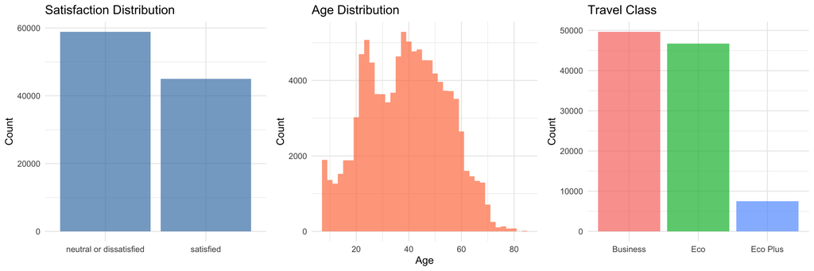

```r
p1 <- ggplot(airline_data, aes(x = satisfaction)) +
  geom_bar(fill = "steelblue", alpha = 0.7) +
  labs(title = "Satisfaction Distribution", y = "Count", x = "") +
  theme_minimal()

p2 <- ggplot(airline_data, aes(x = Age)) +
  geom_histogram(bins = 40, fill = "coral", alpha = 0.7) +
  labs(title = "Age Distribution", y = "Count") +
  theme_minimal()

p3 <- ggplot(airline_data, aes(x = Class, fill = Class)) +
  geom_bar(alpha = 0.7) +
  labs(title = "Travel Class", y = "Count", x = "") +
  theme_minimal() +
  theme(legend.position = "none")

gridExtra::grid.arrange(p1, p2, p3, ncol = 3)
```

# 2. Exploratory Factor Analysis

## Objective

Reduce 14 feedback variables into meaningful latent dimensions representing underlying service quality constructs.

## Data Suitability Assessment

```r
# Extract feedback data
feedback_data <- airline_data %>%
  select(all_of(feedback_features)) %>%
  na.omit()

# KMO Test
kmo_result <- KMO(feedback_data)

# Bartlett's Test
bart_test <- cortest.bartlett(cor(feedback_data), n = nrow(feedback_data))

# Create table
suitability <- data.frame(
  Test = c("Kaiser-Meyer-Olkin (KMO)", "Bartlett's Test", "Sample Size"),
  Value = c(
    round(kmo_result$MSA, 3),
    "χ² statistic",
    format(nrow(feedback_data), big.mark = ",")
  ),
  Result = c(
    ifelse(kmo_result$MSA > 0.8, "Excellent ✓",
           ifelse(kmo_result$MSA > 0.7, "Good ✓", "Adequate")),
    ifelse(bart_test$p.value < 0.001, "p < 0.001 ✓", "Not significant"),
    "Sufficient"
  )
)

kable(suitability, caption = "Factor Analysis Suitability Tests") %>%
  kable_styling(bootstrap_options = c("striped", "hover"), full_width = FALSE)
```

Factor Analysis Suitability Tests

| Test | Value | Result |
| --- | --- | --- |
| Kaiser-Meyer-Olkin (KMO) | 0.781 | Good ✓ |
| Bartlett’s Test | χ² statistic | p < 0.001 ✓ |
| Sample Size | 103,904 | Sufficient |

## Parallel Analysis

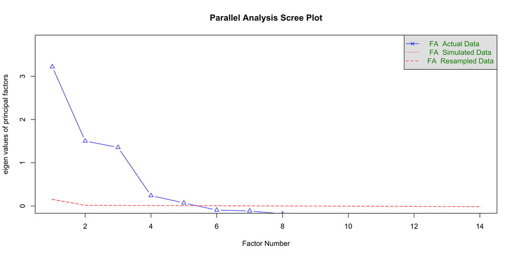

```
## Parallel analysis suggests that the number of factors =  5  and the number of components =  NA
```

```r
set.seed(42)
parallel_result <- fa.parallel(feedback_data, fm = "ml", fa = "fa",
                               main = "Parallel Analysis Scree Plot",
                               show.legend = TRUE)
```

```r
n_factors <- parallel_result$nfact
```

**Recommended factors**: **5** (based on parallel analysis - the gold standard)

## Factor Extraction & Loadings

```r
# Perform EFA
efa_model <- fa(feedback_data,
                nfactors = n_factors,
                rotate = "oblimin",
                fm = "ml",
                scores = TRUE)

# Variance explained
var_table <- data.frame(
  Factor = paste0("Factor ", 1:n_factors),
  SS_Loadings = efa_model$Vaccounted[1, 1:n_factors],
  Prop_Var = efa_model$Vaccounted[2, 1:n_factors],
  Cumulative = efa_model$Vaccounted[3, 1:n_factors]
)

kable(var_table, digits = 3,
      col.names = c("Factor", "SS Loadings", "Proportion Var", "Cumulative Var"),
      caption = "Variance Explained by Each Factor") %>%
  kable_styling(bootstrap_options = c("striped", "hover"))
```

Variance Explained by Each Factor

|  | Factor | SS Loadings | Proportion Var | Cumulative Var |
| --- | --- | --- | --- | --- |
| ML1 | Factor 1 | 2.707 | 0.193 | 0.193 |
| ML3 | Factor 2 | 2.210 | 0.158 | 0.351 |
| ML2 | Factor 3 | 1.952 | 0.139 | 0.491 |
| ML4 | Factor 4 | 0.910 | 0.065 | 0.556 |
| ML5 | Factor 5 | 0.485 | 0.035 | 0.590 |

### Factor Loadings Matrix

```r
loadings_df <- as.data.frame(unclass(efa_model$loadings))
loadings_df$Variable <- rownames(loadings_df)
loadings_df <- loadings_df %>%
  select(Variable, everything())

# Clean variable names
loadings_df$Variable <- gsub("\\.", " ", loadings_df$Variable)

# Round numeric columns
loadings_df[, -1] <- round(loadings_df[, -1], 3)

kable(loadings_df, caption = "Factor Loadings (Pattern Matrix)") %>%
  kable_styling(bootstrap_options = c("striped", "hover"),
                font_size = 11) %>%
  row_spec(0, bold = TRUE)
```

Factor Loadings (Pattern Matrix)

|  | Variable | ML1 | ML3 | ML2 | ML4 | ML5 |
| --- | --- | --- | --- | --- | --- | --- |
| Inflight.wifi.service | Inflight wifi service | 0.025 | 0.044 | 0.802 | 0.047 | -0.076 |
| Departure.Arrival.time.convenient | Departure Arrival time convenient | 0.036 | 0.089 | 0.205 | 0.581 | 0.141 |
| Ease.of.Online.booking | Ease of Online booking | -0.085 | -0.032 | 0.841 | 0.200 | -0.042 |
| Gate.location | Gate location | 0.076 | -0.034 | 0.237 | 0.575 | -0.045 |
| Food.and.drink | Food and drink | 0.801 | -0.140 | -0.010 | 0.041 | -0.051 |
| Online.boarding | Online boarding | 0.164 | 0.018 | 0.617 | -0.336 | 0.316 |
| Seat.comfort | Seat comfort | 0.764 | -0.052 | 0.012 | -0.018 | 0.219 |
| Inflight.entertainment | Inflight entertainment | 0.801 | 0.310 | 0.054 | -0.067 | -0.247 |
| On.board.service | On board service | 0.029 | 0.695 | 0.034 | -0.051 | 0.025 |
| Leg.room.service | Leg room service | 0.004 | 0.459 | 0.131 | -0.083 | -0.037 |
| Baggage.handling | Baggage handling | -0.026 | 0.773 | -0.015 | 0.034 | 0.034 |
| Checkin.service | Checkin service | 0.064 | 0.336 | -0.082 | 0.099 | 0.472 |
| Inflight.service | Inflight service | -0.025 | 0.812 | -0.024 | 0.034 | 0.007 |
| Cleanliness | Cleanliness | 0.867 | -0.061 | -0.039 | 0.045 | 0.098 |